# Chi squared test

20 okt 2016

## Inhoud

## \(\chi^2\) test

Relation between categorical variables

## \(\chi^2\) test

Source: [wikipedia](https://en.wikipedia.org/wiki/Chi-squared_test)

## \(\chi^2\) test statistic

\[\chi^2 = \sum \frac{(\text{observed}_{ij} - \text{model}_{ij})^2}{\text{model}_{ij}}\]

### Contingency table

\[\text{observed}_{ij} = \begin{pmatrix} o_{11} & o_{12} & \cdots & o_{1j} \\ o_{21} & o_{22} & \cdots & o_{2j} \\ \vdots & \vdots & \ddots & \vdots \\ o_{i1} & o_{i2} & \cdots & o_{ij} \end{pmatrix}\]

\[\text{model}_{ij} = \begin{pmatrix} m_{11} & m_{12} & \cdots & m_{1j} \\ m_{21} & m_{22} & \cdots & m_{2j} \\ \vdots & \vdots & \ddots & \vdots \\ m_{i1} & m_{i2} & \cdots & m_{ij} \end{pmatrix}\]

## \(\chi^2\) distribution

The \(\chi^2\) distribution describes the test statistic under the assumption of \(H_0\), given the degrees of freedom.

\(df = (r - 1) (c - 1)\) where \(r\) is the number of rows and \(c\) the amount of columns.

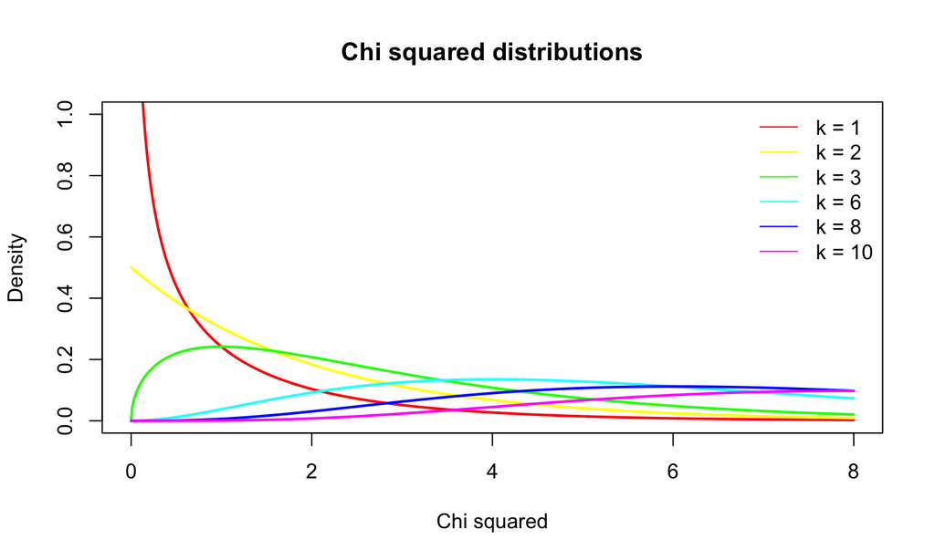

```r
chi = seq(0,8,.01)
df  = c(1,2,3,6,8,10)
col = rainbow(n = length(df))

plot( chi, dchisq(chi, df[1]), lwd = 2, col = col[1], type="l",
      main = "Chi squared distributions",
      ylab = "Density",
      ylim = c(0,1),
      xlab = "Chi squared")

lines(chi, dchisq(chi, df[2]), lwd = 2, col = col[2], type="l")
lines(chi, dchisq(chi, df[3]), lwd = 2, col = col[3], type="l")
lines(chi, dchisq(chi, df[4]), lwd = 2, col = col[4], type="l")
lines(chi, dchisq(chi, df[5]), lwd = 2, col = col[5], type="l")
lines(chi, dchisq(chi, df[6]), lwd = 2, col = col[6], type="l")

legend("topright", legend = paste("k =",df), col = col, lty = 1, bty = "n")
```

## Example

[interactive chart not shown]

## Experiment

[figure not shown]

http://goo.gl/faj76B

## Data

|  | Timestamp | fluiten | frequentie | assertief | sekse | leeftijd |
| --- | --- | --- | --- | --- | --- | --- |
| 1 | 03/10/2013 20:29:17 | Ja | 23 | 3 | Man | 12 |
| 2 | 03/10/2013 20:30:11 | Ja | 34 | 1 | Man | 23 |
| 3 | 03/10/2013 20:30:31 | Nee | 48 | 5 | Man | 98 |
| 4 | 03/10/2013 20:38:34 | Nee | 21 | 5 | Vrouw | 29 |
| 5 | 03/10/2013 20:51:40 | Ja | 78 | 5 | Vrouw | 33 |
| 6 | 04/10/2013 11:13:15 | Ja | 0 | 4 | Man | 21 |
| 7 | 04/10/2013 11:13:16 | Ja | 5 | 4 | Vrouw | 20 |
| 8 | 04/10/2013 11:13:17 | Ja | 10 | 4 | Man | 34 |
| 9 | 04/10/2013 11:13:22 | Ja | 0 | 4 | Vrouw | 21 |
| 10 | 04/10/2013 11:13:24 | Ja | 2 | 3 | Vrouw | 19 |

[output cut: 198 more lines]

## Calculating \(\chi^2\)

```r
observed <- table(data[,c('fluiten','sekse')])
observed
```

```
##        sekse
## fluiten Man Vrouw
##     Ja   46   112
##     Nee   7    43
```

\[\text{observed}_{ij} = \begin{pmatrix} 46 & 112 \\ 7 & 43 \\ \end{pmatrix}\]

## Calculating the model

\[\text{model}_{ij} = E_{ij} = \frac{\text{row total}_i \times \text{column total}_j}{n }\]

```r
n   = sum(observed)
ct1 = colSums(observed)[1]
ct2 = colSums(observed)[2]
rt1 = rowSums(observed)[1]
rt2 = rowSums(observed)[2]

addmargins(observed)
```

```
##        sekse
## fluiten Man Vrouw Sum
##     Ja   46   112 158
##     Nee   7    43  50
##     Sum  53   155 208
```

## Calculating the model

\[\text{model}_{ij} = E_{ij} = \frac{\text{row total}_i \times \text{column total}_j}{n }\]

```r
model = matrix( c((ct1*rt1)/n,
                  (ct2*rt1)/n,
                  (ct1*rt2)/n,
                  (ct2*rt2)/n),2,2,byrow=T
          )
model
```

```
##          [,1]      [,2]
## [1,] 40.25962 117.74038
## [2,] 12.74038  37.25962
```

\[\text{model}_{ij} = \begin{pmatrix} 40.2596154 & 117.7403846 \\ 12.7403846 & 37.2596154 \\ \end{pmatrix}\]

## observed - model

```r
observed - model
```

```
##        sekse
## fluiten       Man     Vrouw
##     Ja   5.740385 -5.740385
##     Nee -5.740385  5.740385
```

## Calculating \(\chi^2\)

\[\chi^2 = \sum \frac{(\text{observed}_{ij} - \text{model}_{ij})^2}{\text{model}_{ij}}\]

```r
# Calculate chi squared
chi.squared <- sum((observed - model)^2/model)
chi.squared
```

```
## [1] 4.56917
```

## Testing for significance

\(df = (r - 1) (c - 1)\)

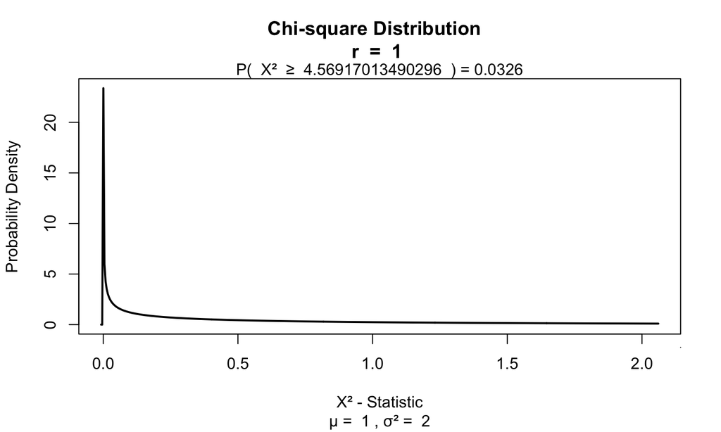

```r
df = (2 - 1) * ( 2 - 1)

library('visualize')
visualize.chisq(chi.squared,df,section='upper')
```

## Fisher's exact test

Calculates axact \(\chi^2\) for small samples

## Likelihood ratio

\[L \chi^2 = 2 \sum \text{observed}_{ij} ln \left( \frac{\text{observed}_{ij}}{\text{model}_{ij}} \right)\]

```r
# ln is log
lx2 = 2 * sum(observed * log(observed / model) ); lx2
```

```
## [1] 5.005489
```

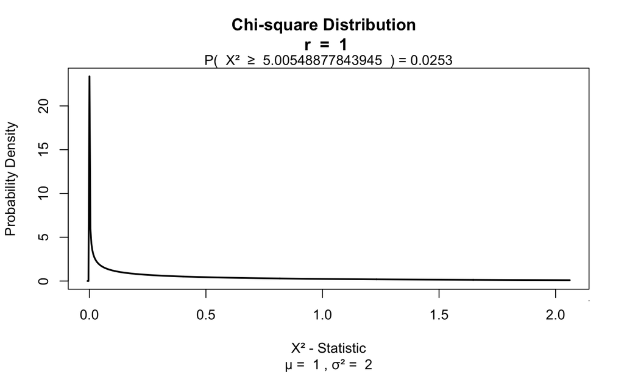

```r
visualize.chisq(lx2,df,section='upper')
```

## Yates's correction

For 2 x 2 contingency tables.

\[\chi^2 = \sum \frac{ ( | \text{observed}_{ij} - \text{model}_{ij} | - .5)^2}{\text{model}_{ij}}\]

```r
# Calculate Yates's corrected chi squared
chi.squared.yates <- sum((abs(observed - model) - .5)^2/model)
chi.squared.yates
```

```
## [1] 3.807866
```

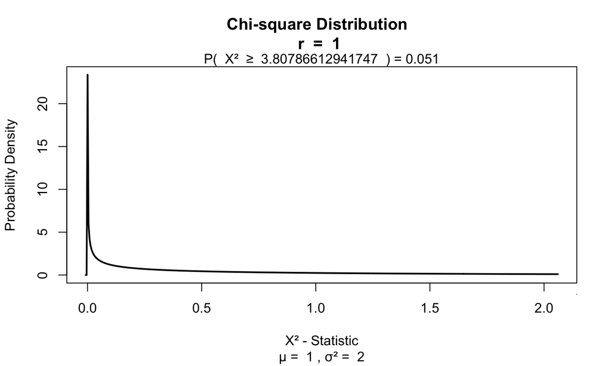

```r
visualize.chisq(chi.squared.yates,df,section='upper')
```

## Standardized residuals

\[\text{standardized residuals} = \frac{ \text{observed}_{ij} - \text{model}_{ij} }{ \sqrt{ \text{model}_{ij} } }\]

```r
(observed - model) / sqrt(model)
```

```
##        sekse
## fluiten        Man      Vrouw
##     Ja   0.9047033 -0.5290275
##     Nee -1.6082358  0.9404199
```

## Effect size

```r
odds <- round( observed, 2); odds
```

```
##        sekse
## fluiten Man Vrouw
##     Ja   46   112
##     Nee   7    43
```

\[\begin{pmatrix} a & b \\ c & d \\ \end{pmatrix}\]

\[OR = \frac{a \times d}{b \times c} = \frac{46 \times 43}{112 \times 7} = 2.5229592\]

## Odds

```
##        sekse
## fluiten Man Vrouw
##     Ja   46   112
##     Nee   7    43
```

The man and women ratio of people that can whisle and the ratio of those who can't whistle

- Can wistle \(\text{Odds}_{mf} = \frac{ 46 }{ 112 }\) = 0.4107143
- Can't wistle \(\text{Odds}_{mf} = \frac{ 7 }{ 43 }\) = 0.1627907

## Odds ratio

Is the ratio of these odds.

\[OR = \frac{\text{wistle}}{\text{can't wistle}} = \frac{0.4107143}{0.1627907} = 2.5229592\]

## Simulation

```r
chi.values = vector()

for(i in 1:1000) {

    # Simulate non correlated data

    x = rbinom(73,1,.5)
    y = rbinom(73,1,.5)

    data = data.frame(x,y)

    observed <- as.matrix(table(data))

    chi.values[i] = chisq.test(observed,1,correct=FALSE)$statistic

}
```

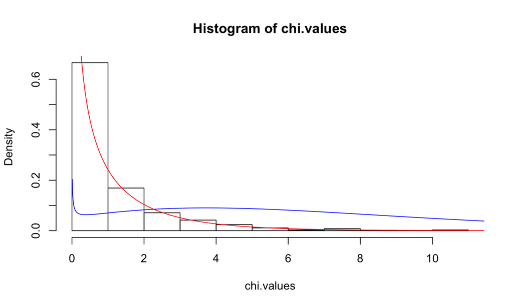

```r
hist(chi.values,freq=F)
chi = seq(0,20,.01)
lines(chi,dchisq(chi,1),         lty=1,col='red',  cex=2) # Chi distribution under H0
lines(chi,dchisq(chi,1, ncp = 6),lty=1,col='blue', cex=2) # Chi distribution under HA
```

## END

[@shklinkenberg](https://twitter.com/shklinkenberg)